# Stat340 Progress V2

## R Markdown

```r
library(tidyverse)
mvp <- read.csv("nbamvp.csv")
player_stats <- read.csv("all_nba_team.csv")
player_stats <- player_stats %>%
  mutate(Year = ï..YEAR)
head(player_stats)
```

```
##   ï..YEAR                PLAYER POS                  TEAM   FG.  PPG  RPG  APG
## 1    2021         Stephen Curry  PG Golden State Warriors 0.482 32.0  5.5  5.8
## 2    2021         Kawhi Leonard  SF           LA Clippers 0.512 24.8  6.5  5.2
## 3    2021 Giannis Antetokounmpo  PF       Milwaukee Bucks 0.569 28.1 11.0  5.9
## 4    2021          Nikola Jokic   C        Denver Nuggets 0.566 26.4 10.8  8.3
## 5    2021           Luka Doncic  PG      Dallas Mavericks 0.479 27.7  8.0  8.6
## 6    2020          LeBron James   F    Los Angeles Lakers 0.493 25.3  7.8 10.2
##   BLKPG MVP Year
## 1   0.1   0 2021
## 2   0.4   0 2021
## 3   1.2   0 2021
## 4   0.7   1 2021
## 5   0.5   0 2021
## 6   0.5   0 2020
```

```r
logistic_lr <- glm(MVP ~ 1 + FG. + PPG + RPG + APG + BLKPG, data = player_stats, family = 'binomial')
summary(logistic_lr)
```

```
##
## Call:
## glm(formula = MVP ~ 1 + FG. + PPG + RPG + APG + BLKPG, family = "binomial",
##     data = player_stats)
##
## Deviance Residuals:
##     Min       1Q   Median       3Q      Max
## -1.3058  -0.6614  -0.4632  -0.3088   2.2572
##
## Coefficients:
##              Estimate Std. Error z value Pr(>|z|)
## (Intercept) -12.51936    4.12833  -3.033  0.00242 **
## FG.           9.18222    6.64577   1.382  0.16708
## PPG           0.13592    0.06041   2.250  0.02446 *
## RPG           0.08540    0.14041   0.608  0.54305
## APG           0.35251    0.14334   2.459  0.01392 *
## BLKPG         0.17719    0.60876   0.291  0.77100
## ---
## Signif. codes:  0 '***' 0.001 '**' 0.01 '*' 0.05 '.' 0.1 ' ' 1
##
## (Dispersion parameter for binomial family taken to be 1)
##
##     Null deviance: 110.089  on 109  degrees of freedom
## Residual deviance:  96.694  on 104  degrees of freedom
## AIC: 108.69
##
## Number of Fisher Scoring iterations: 5
```

After doing some research online, I found out that normal residual plot are not very useful for logistic regression. It is much better to use a binned residual plot. I copied and pasted the binned plot function below as I couldn’t get the ‘arm’ package which is where binned plot is located to install.

```r
binnedplot <- function(x, y, nclass=NULL,
    xlab="Expected Values", ylab="Average residual",
    main="Binned residual plot",
    cex.pts=0.8, col.pts=1, col.int="gray", ...)
{

    n <- length(x)
    if (is.null(nclass)){
        if (n >= 100){
            nclass=floor(sqrt(length(x)))
        }
        if (n > 10 & n < 100){
            nclass=10
        }
        if (n <=10){
            nclass=floor(n/2)
        }
    }

    aa <- data.frame(binned.resids (x, y, nclass)$binned)
    plot(range(aa$xbar), range(aa$ybar, aa$X2se, -aa$X2se, na.rm=TRUE),
        xlab=xlab, ylab=ylab, type="n", main=main, ...)
    abline (0,0, lty=2)
    lines (aa$xbar, aa$X2se, col=col.int)
    lines (aa$xbar, -aa$X2se, col=col.int)
    points (aa$xbar, aa$ybar, pch=19, cex=cex.pts, col=col.pts)
}

binned.resids <- function (x, y, nclass=floor(sqrt(length(x)))){

    breaks.index <- floor(length(x)*(1:(nclass-1))/nclass)
    if(any(breaks.index==0)) nclass <- 1
    x.sort <- sort(x)
    breaks <- -Inf
    if(nclass > 1){
      for (i in 1:(nclass-1)){
        x.lo <- x.sort[breaks.index[i]]
        x.hi <- x.sort[breaks.index[i]+1]
        if (x.lo==x.hi){
            if (x.lo==min(x)){
                x.lo <- -Inf
            }
            else {
                x.lo <- max (x[x<x.lo])
            }
        }
        breaks <- c (breaks, (x.lo + x.hi)/2)
      }
    }else if(nclass ==1){
      x.lo <- min(x)
      x.hi <- max(x)
      breaks <- c (breaks, (x.lo + x.hi)/2)
    }

    breaks <- c (breaks, Inf)
    breaks <- unique(breaks)
    nclass <- length(breaks) - 1
    output <- NULL
    xbreaks <- NULL
    x.binned <- as.numeric (cut (x, breaks))

    for (i in 1:nclass){
        items <- (1:length(x))[x.binned==i]
        x.range <- range(x[items])
        xbar <- mean(x[items])
        ybar <- mean(y[items])
        n <- length(items)
        #p <- xbar
        #sdev <- sd(y[items])
        sdev <- if(length(y[items]) > 1) sd(y[items]) else 0
        output <- rbind (output, c(xbar, ybar, n, x.range, 2*sdev/sqrt(n)))

    }

    colnames (output) <- c("xbar", "ybar", "n", "x.lo", "x.hi", "2se")
    #output <- output[output[,"sdev"] != 0,]
    return (list (binned=output, xbreaks=xbreaks))
}
```

```r
library(ISLR)
```

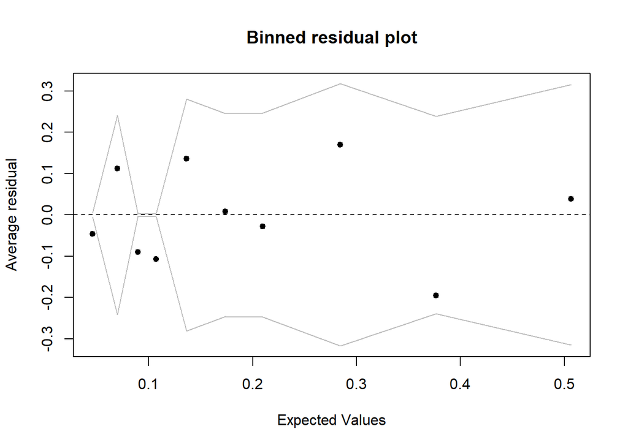

```r
binnedplot(fitted(logistic_lr),
           residuals(logistic_lr, type = "response"),
           nclass = NULL,
           xlab = "Expected Values",
           ylab = "Average residual",
           main = "Binned residual plot",
           cex.pts = 0.8,
           col.pts = 1,
           col.int = "gray")
```

The grey lines represent ± 2 SE bands, which we would expect to contain about 95% of the observations. This model looks somewhat reasonable as the that majority of the fitted values seem to fall within the SE bands. There are some fitted values, mainly the ones under 0.1, that seem to be outside the SE bands. Another thing to notice is that all of the outliers are negative which seems to sugest that the model is actually predicitng a higher rate of MVPs than is actually the case.

## K-means Clustering

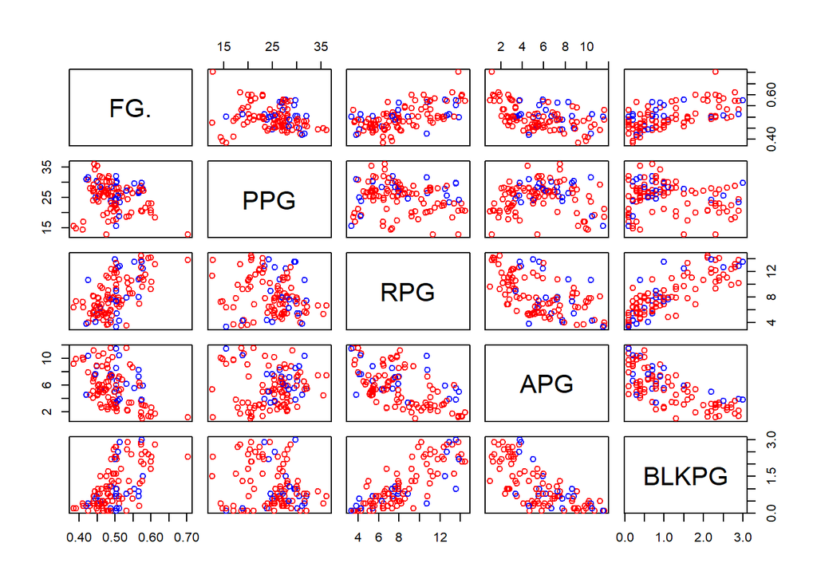

```r
mvp_colors <- c("red", "blue")[unclass(as.factor(player_stats$MVP))]
pairs(player_stats[,5:9], col=mvp_colors)
```

Here we have a pairs plot showing a bunch of relationships between different player statistics, with coloring to represent which data points are mvp seasons, and which are not. Just from a first look, it appears as if there is not a clear cluster of mvps in any of the relationships. Regardless, we will press on and see if k-means clustering can pick out which points are mvps.

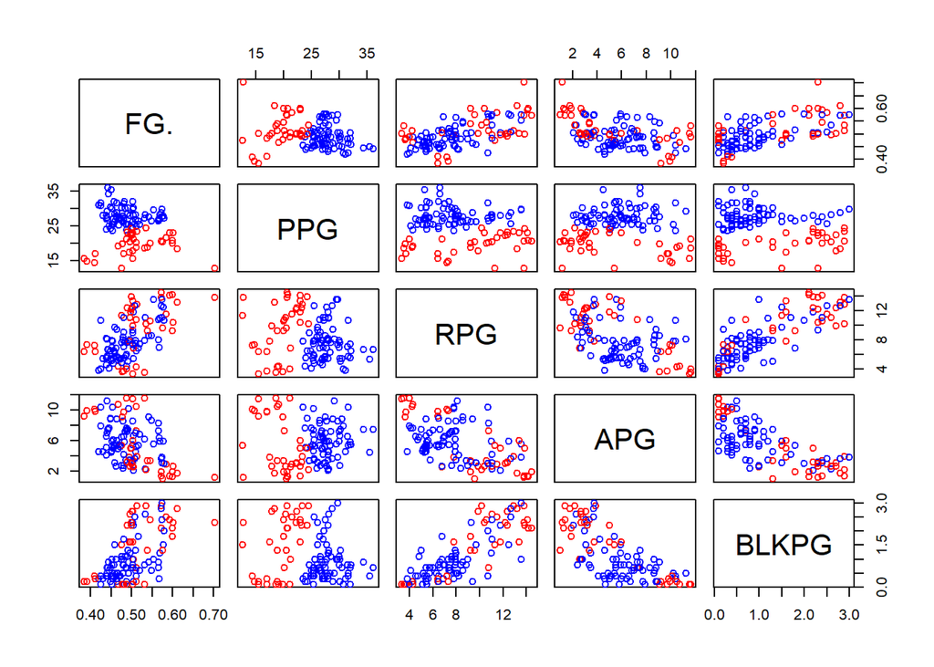

```r
k_mvp <- kmeans(player_stats[,5:9], centers = 2, nstart = 50)
k_mvp_colors <- c("red", "blue")[k_mvp$cluster]
pairs(player_stats[,5:9], col = k_mvp_colors)
```

Based on the observations of the last plot, the kmeans clustering was extremely ineffective at determining mvp seasons, because they lacked a clear pattern. Therefore these plots are unlikely to make it into our final draft.